# U.S. Census Modeling

TJ Schaeffer

Due: 02/10/2019

`r`r # Packages library(ggplot2) library(mdsr) library(tidyverse) library(lubridate) library(mosaic) library(mosaicData) library(NHANES) library(macleish) library(babynames) library(Hmisc) library(rvest) library(readr) # user-defined functions here (if any) # measure_dist with USCensus # measure_dist2 with USCenus # opmodel1 with USCensus # load data # data USCensusRaw

# Project tasks

*Article 1 of the United States Constitution actually mandates that a census of the US population be taken every 10 years. This has various purposes, including reallocation of seats in the U.S. House of Representives based on relative population of each state. Population growth is typically not linear (as we’ll see).*

*You will scrape and clean the US Census data from Wikipedia, and then fit an exponential model of the form:*

$$y = \frac{\beta_1}{1 + \exp(\beta_2 + \beta_3*x)}$$

*where* y* is the total population in the US at the time of the census taken at time *x*. This is the model family, and you will use R’s `optim` function to estimate the parameters $\beta_1, \beta_2, \& \beta_3$ for the non-linear model that best fits the data.*

## 0. [1 pt] Get ready for the census taker!

**Task 0.1 Just for fun, embed the image “farmers.jpg” showing an 1940’s advertisement from the US Census Bureau here. Be sure to include the following image caption: “Image source: https://catalog.archives.gov/id/514239”**

[figure not shown]

Image source:https://catalog.archives.gov/id/514239

## 1. Data Preparation

### 1.1 [2 pts] Scrape the source data

**Task 1.1.1 Scrape and inspect the population data for all decennial U.S. Census results from 1790 through 2010 from Wikipedia (link: https://en.wikipedia.org/wiki/United_States_Census). Call the resulting data structure `USCensusRaw`.**

**Task 1.1.2 Be sure to inspect the `USCensusRaw` data structure and show a few rows of the data before any processing/cleaning.**

`r`r # Inspecting data USCensusRaw

| Year | Total population | Progress | Most populated state | Most populated city | Slaves | Notes |
| --- | --- | --- | --- | --- | --- | --- |
| 1790[c] | 3,929,326[d] | — | Virginia(747,610) | New York, NY(33,131) | 694,280 | Original numbers were corrected later. |
| 1800[e] | 5,308,483[f] | 35% | Virginia[g](676,682) | New York, NY(60,515) | 893,605[h] | Original numbers were corrected later. |
| 1810[i] | 7,239,881 | 36% | New York(959,049) | New York, NY(96,373) | 1,191,362 | — |
| 1820[j] | 9,638,453 | 33% | New York(1,372,812) | New York, NY(123,706) | 1,538,022 | — |
| 1830[k] | 12,866,020 | 33% | New York(1,918,608) | New York, NY(202,589) | 2,009,043 | — |
| 1840[l] | 17,069,453 | 33% | New York(2,428,921) | New York, NY(312,710) | 2,487,355 | The census estimated the population of the United States at 17,100,000. The results were tabulated by 28 clerks in the Bureau of the Census. |
| 1850[m] | 23,191,876 | 36% | New York(3,097,394) | New York, NY(515,547) | 3,204,313 | The 1850 census was a landmark year in American census-taking. It was the first year in which the census bureau attempted to record every member of every household, including women, children and slave… |
| 1860[n] | 31,443,321 | 35% | New York(3,880,735) | New York, NY(813,669) | 3,953,761 | The results were tabulated by 184 clerks in the Bureau of the Census. This was the first census where the American Indians officially were counted, but only those who had 'renounced tribal rules'. The… |
| 1870[o] | 39,818,449[p] | 23% | New York(4,382,759) | New York, NY(942,292) | — | The first census to provide detailed information on the black population, only years after the culmination of the Civil War when slaves were granted freedom. The results are controversial, as many bel… |
| 1880[q] | 50,189,209 | 30% | New York(5,082,871) | New York, NY(1,206,299) | — | The first census that permitted women to be enumerators. Also led to the discovery of Alabama paradox. |

[output cut: 13 more lines]

### 1.2 [5 pts] Data cleansing

*A bit of cleaning is necessary to prepare the data for further analysis. It’s a good idea to keep an unchanged copy of the complete source data around (i.e., `USCensusRaw`) when possible. The cleaned/processed data should be given a new name: `USCensus`.*

**Task 1.2.1 For example, your code should use regular expressions to identify and eliminate all footnoote references in the date column. You can also drop the notes column, since we won’t be using it for analysis. Other simple cleaning operations will be necessary as you complete your analysis; you’ll figure them out along the way, but your code for those steps belongs here.**

`r`r # Cleaning data USCensusRaw$Notes <- NULL census <- c(0:22) USCensus <- USCensusRaw %>% mutate(Year = parse_number(Year), `Total population`= parse_number(`Total population`), popMillions = round(`Total population` / 1000000, digits = 3)) %>% cbind(census)

**Task 1.2.2 Be sure to inspect the `USCensus` data structure and show a few rows of the cleaned table.**

`r`r # Inspecting data USCensus

| Year | Total population | Progress | Most populated state | Most populated city | Slaves | popMillions | census |
| --- | --- | --- | --- | --- | --- | --- | --- |
| 1790 | 3929326 | — | Virginia(747,610) | New York, NY(33,131) | 694,280 | 3.929 | 0 |
| 1800 | 5308483 | 35% | Virginia[g](676,682) | New York, NY(60,515) | 893,605[h] | 5.308 | 1 |
| 1810 | 7239881 | 36% | New York(959,049) | New York, NY(96,373) | 1,191,362 | 7.240 | 2 |
| 1820 | 9638453 | 33% | New York(1,372,812) | New York, NY(123,706) | 1,538,022 | 9.638 | 3 |
| 1830 | 12866020 | 33% | New York(1,918,608) | New York, NY(202,589) | 2,009,043 | 12.866 | 4 |
| 1840 | 17069453 | 33% | New York(2,428,921) | New York, NY(312,710) | 2,487,355 | 17.069 | 5 |
| 1850 | 23191876 | 36% | New York(3,097,394) | New York, NY(515,547) | 3,204,313 | 23.192 | 6 |
| 1860 | 31443321 | 35% | New York(3,880,735) | New York, NY(813,669) | 3,953,761 | 31.443 | 7 |
| 1870 | 39818449 | 23% | New York(4,382,759) | New York, NY(942,292) | — | 39.818 | 8 |
| 1880 | 50189209 | 30% | New York(5,082,871) | New York, NY(1,206,299) | — | 50.189 | 9 |

[output cut: 13 more lines]

## 2. [8 pts] Exploratory Data Analysis

*We should almost always plot our data to try and better understand it’s structure before proceding with analysis.*

**Task 2.1 show a scatter plot of population (in millions, rounded to 3rd decimal place; call it `popMillions`) and add a smoother (e.g. loess) to the plot. Make sure your plot includes descriptive axis labels and an informative title.**

`r`r # Scatterplot USCensus %>% ggplot(aes(x = Year, y = popMillions)) + geom_point() + geom_smooth(method = loess, se = FALSE) + ggtitle(Populatins Over Time) + ylab(Populaion (in millions)

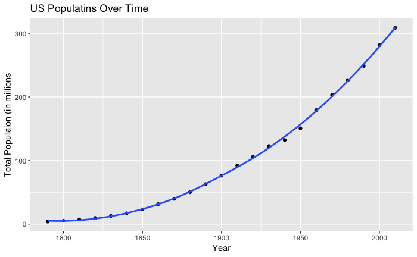

**Task 2.2: show the same plot with a line of best fit (rather than the smoother).**

`r`r # Line of best fit USCensus %>% ggplot(aes(x = Year, y = popMillions)) + geom_point() + geom_smooth(method = lm, se = FALSE) + ggtitle(Populatins Over Time) + ylab(Populaion (in millions)

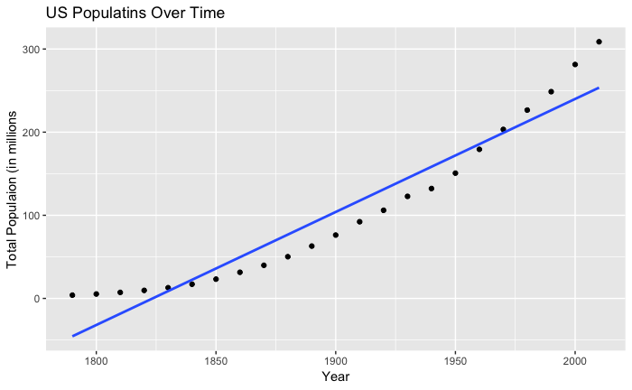

**Task 2.3: explain why the linear model is NOT useful here. it’s okay to state the obvious, but try to be specific.** ** The linear model is not useful because the data follows an exponetial curve. The linear model does not pass through a majority of the points as well. **

## 3. [8 pts] Non-linear model fit (`optim` with RMS distance metric)

*For the purpose of modeling we will use an index for each census as our explanatory variable instead of `year`. Call the index `census`, and add it to the data back in your “data cleansing” task earlier in the assignment. The `census` index should start at 0 (zero) for the 1790 census, and increment for each subsequent census (1 for 1800, 2 for 1810, and so on). In other words, we want to assume that 1790 is “time 0” because we can use that (with a little algebra) to solve for reasonable estimates for our three model parameters. I’ll spare you the trouble, but you should start with the following estimates:*

- *$\beta_1 \approx 400$; you can think of $\beta_1$ as something like an upper-bound for the US poplation. Certainly there are many countries populated far more densely than the U.S., but we also wouldn’t want to extrapolate* too* dramatically and some have even begun to argue that the US (and other countries) has already exceeded it’s sustainable carrying capacity. [^1]*
- *$\beta_2 \approx 4.5$; reflects size of population at time 0, adjusted for the upper-bound of the population.*
- *$\beta_3 \approx -0.3$; controls growth rate of the population.*

**Task 3.1 Store predicted values for the initial model of `popMillions` vs `census` (our index variable) using the provided starting values as a vector called `initialPreds` in the `USCensus` data. What population does this initial model estimate for year 2010?**

`r`r # Finding predicted values initalPreds <- 400 / (1 + exp(4.5 - (0.3 * USCensus$census))) USCensus <- USCensus %>% cbind(initalPreds) USCensus

| Year | Total population | Progress | Most populated state | Most populated city | Slaves | popMillions | census | initalPreds |
| --- | --- | --- | --- | --- | --- | --- | --- | --- |
| 1790 | 3929326 | — | Virginia(747,610) | New York, NY(33,131) | 694,280 | 3.929 | 0 | 4.394777 |
| 1800 | 5308483 | 35% | Virginia[g](676,682) | New York, NY(60,515) | 893,605[h] | 5.308 | 1 | 5.909613 |
| 1810 | 7239881 | 36% | New York(959,049) | New York, NY(96,373) | 1,191,362 | 7.240 | 2 | 7.936122 |
| 1820 | 9638453 | 33% | New York(1,372,812) | New York, NY(123,706) | 1,538,022 | 9.638 | 3 | 10.638797 |
| 1830 | 12866020 | 33% | New York(1,918,608) | New York, NY(202,589) | 2,009,043 | 12.866 | 4 | 14.228476 |
| 1840 | 17069453 | 33% | New York(2,428,921) | New York, NY(312,710) | 2,487,355 | 17.069 | 5 | 18.970349 |
| 1850 | 23191876 | 36% | New York(3,097,394) | New York, NY(515,547) | 3,204,313 | 23.192 | 6 | 25.189342 |
| 1860 | 31443321 | 35% | New York(3,880,735) | New York, NY(813,669) | 3,953,761 | 31.443 | 7 | 33.269079 |
| 1870 | 39818449 | 23% | New York(4,382,759) | New York, NY(942,292) | — | 39.818 | 8 | 43.638728 |
| 1880 | 50189209 | 30% | New York(5,082,871) | New York, NY(1,206,299) | — | 50.189 | 9 | 56.740426 |

[output cut: 13 more lines]

**Task 3.2 Store residuals for the initial model of `popMillions` vs `census` (our index variable) using the provided starting values as a vector called `initialResids` in the `USCensus` data. Interpret the residual for the 2010 census.**

`r`r # Finding residual initalResids <- USCensus$popMillions - USCensus$initalPreds USCensus <- USCensus %>% cbind(initalResids) USCensus

| Year | Total population | Progress | Most populated state | Most populated city | Slaves | popMillions | census | initalPreds | initalResids |
| --- | --- | --- | --- | --- | --- | --- | --- | --- | --- |
| 1790 | 3929326 | — | Virginia(747,610) | New York, NY(33,131) | 694,280 | 3.929 | 0 | 4.394777 | -0.4657771 |
| 1800 | 5308483 | 35% | Virginia[g](676,682) | New York, NY(60,515) | 893,605[h] | 5.308 | 1 | 5.909613 | -0.6016127 |
| 1810 | 7239881 | 36% | New York(959,049) | New York, NY(96,373) | 1,191,362 | 7.240 | 2 | 7.936122 | -0.6961223 |
| 1820 | 9638453 | 33% | New York(1,372,812) | New York, NY(123,706) | 1,538,022 | 9.638 | 3 | 10.638797 | -1.0007974 |
| 1830 | 12866020 | 33% | New York(1,918,608) | New York, NY(202,589) | 2,009,043 | 12.866 | 4 | 14.228476 | -1.3624757 |
| 1840 | 17069453 | 33% | New York(2,428,921) | New York, NY(312,710) | 2,487,355 | 17.069 | 5 | 18.970349 | -1.9013493 |
| 1850 | 23191876 | 36% | New York(3,097,394) | New York, NY(515,547) | 3,204,313 | 23.192 | 6 | 25.189342 | -1.9973424 |
| 1860 | 31443321 | 35% | New York(3,880,735) | New York, NY(813,669) | 3,953,761 | 31.443 | 7 | 33.269079 | -1.8260786 |
| 1870 | 39818449 | 23% | New York(4,382,759) | New York, NY(942,292) | — | 39.818 | 8 | 43.638728 | -3.8207285 |
| 1880 | 50189209 | 30% | New York(5,082,871) | New York, NY(1,206,299) | — | 50.189 | 9 | 56.740426 | -6.5514260 |

[output cut: 13 more lines]

** The 2010 residual was negative, which means that estimated population for the year 2010 was greater than the actual population in the year 2010. **

**Task 3.3 Calculate and show the root-mean-square (RMS) distance metric for our initial model.**

`r`r # Calculate the RMS sqrt(mean(USCensus$initalResids ^ 2))

```
[1] 45.17575
```

**Task 3.4 Produce and report optimal parameter estimates for beta1, beta2, and beta3 using the RMS distance metric. Interpret the estimates for beta1 and beta3 in the context of the study.**

`r`r # Craft a function to find optimal paramaters opmodel1 <- function(o) { o[1] / (1 + exp(o[2] + o[3] * USCensus$census)) } measure_dist <- function(r, data) { diff1 <- data$popMillions - opmodel1(r) sqrt(mean(diff1 ^ 2)) } # Find the optimal parameters estimates for betas optimalnums <- optim(par = c(400,4.5,-0.3), fn = measure_dist, data = USCensus) optimalnums$par

```
[1] 486.8025140   4.0591554  -0.2075431
```

## 4. [4 pts] Non-linear model fit (`optim` with MAD distance metric)

**Task 4.1 Calculate and show the mean absolute deviation (MAD) distance metric for our initial model.**

`r`r # MAD equation mean(abs(USCensus$initalResids))

```
[1] 31.68472
```

**Task 4.2 Produce and report optimal parameter estimates for beta1, beta2, and beta3 using the MAD distance metric. Interpret the estimates for beta1 and beta3 in the context of the study.**

`r`r # Craft a function to find optimal paramaters measure_dist2 <- function(w, data) { diff2 <- data$popMillions - opmodel1(w) mean(abs(diff2)) } bestop2 <- optim(par = c(400, 4.5, -0.3), fn = measure_dist2, data = USCensus) bestop2$par

```
[1] 512.4268595   4.1178662  -0.2054896
```

## 5. Bootstrap confidence intervals for parameter estimates

*As always, it’s important to consider the uncertainty of our estimates. We’ll do so with Bootstrapping.*

### 5.1 RMS model fit

**Task 5.1.1 [2 pts] Generate 1000 (on thousand) bootstrap model fits for the US Census data using RMS distance metric. Use the `head` function to show a few rows of our Bootstrap results, and clearly explain what each column represents.**

`r`r # Bootstrap Bootstrap1 <- mosaic::do(1000) * optim(par = c(400,4.5,-0.3), fn = measure_dist, data = sample_n(USCensus, size = nrow(USCensus), replace =TRUE))$par head(Bootstrap1)

|  | V1 | V2 | V3 |
| --- | --- | --- | --- |
| 1 | 402.9218 | 1.685904 | 40.94630536 |
| 2 | 400.4649 | 2.787047 | 30.05837212 |
| 3 | 399.9366 | 1.943112 | 30.65848526 |
| 4 | 401.5216 | 1.031831 | 0.01791734 |
| 5 | 401.6081 | 1.914040 | -0.06480755 |
| 6 | 400.1672 | 4.309855 | 19.71144863 |

**Task 5.1.2 [1.5 pts] Calculate and report the bootstrap standard errors for beta1, beta2, and beta3.**

`r`r # Standard errors sd(Bootstrap1$V1)

```
[1] 745.1838
```

`r`r sd(Bootstrap1$V2)

```
[1] 59.38963
```

`r`r sd(Bootstrap1$V3)

```
[1] 52.91765
```

**Task 5.1.3 [3 pts] Show a bootstrap sampling distribution for EACH parameter estimate (with informative label or title) and share any pertinent observations.**

`r`r # Bootstrap sample distributions Bootstrap1 %>% ggplot(aes(x = V1)) + geom_histogram()

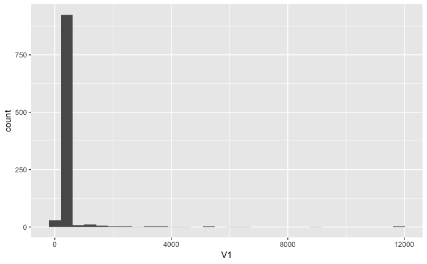

`r`r Bootstrap1 %>% ggplot(aes(x = V2)) + geom_histogram()

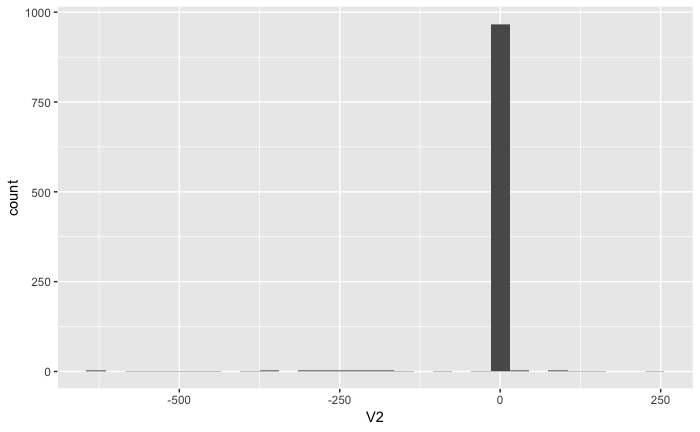

`r`r Bootstrap1 %>% ggplot(aes(x = V3)) + geom_histogram()

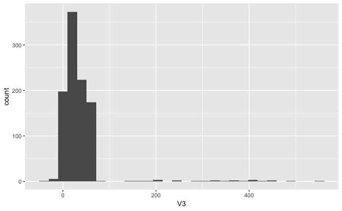

**Task 5.1.4 [3 pts] Calculate and report the bootstrap 95% confidence intervals for beta1, beta2, and beta3.**

`r`r # Boostrap at 95% confidence interval confint(Bootstrap1)

| name | lower | upper | level | method | estimate |
| --- | --- | --- | --- | --- | --- |
| V1 | 186.0796439 | 1468.504488 | 0.95 | percentile | 399.936639 |
| V2 | -29.8992209 | 4.612764 | 0.95 | percentile | 1.943112 |
| V3 | -0.1639193 | 60.945413 | 0.95 | percentile | 30.658485 |

### 5.2 MAD model fit

*Here, you will largely repeat the tasks associated with 5.1, but now using the mean absolute deviation (MAD) distance metric.*

**Task 5.1.1 [2 pts] Generate 1000 (on thousand) bootstrap model fits for the US Census data using MAD distance metric. Use the `head` function to show a few rows of our Bootstrap results, and clearly explain what each column represents.**

`r`r # Generating models Bootstrap2 <- mosaic::do(1000) * optim(par = c(40, 4.5, -0.3), fn = measure_dist2, data = sample_n(USCensus, size = nrow(USCensus), replace = TRUE))$par head(Bootstrap2)

|  | V1 | V2 | V3 |
| --- | --- | --- | --- |
| 1 | 150.69700 | -39.7872631 | -92.873649 |
| 2 | 92.22796 | 0.2747757 | -60.460286 |
| 3 | 48.07780 | -0.6366812 | -6.607567 |
| 4 | 81.33333 | 25.8333333 | -48.300000 |
| 5 | 39.81800 | 11.6947596 | -10.190745 |
| 6 | 106.02200 | -22.4653411 | -50.863966 |

**Task 5.1.2 [1.5 pts] Calculate and report the bootstrap standard errors for beta1, beta2, and beta3 using your MAD model fit.**

`r`r # Find standara deviatons sd(Bootstrap2$V1)

```
[1] 36.32775
```

`r`r sd(Bootstrap2$V2)

```
[1] 26.85151
```

`r`r sd(Bootstrap2$V3)

```
[1] 32.96172
```

**Task 5.1.3 [3 pts] Show a bootstrap sampling distribution for EACH parameter estimate (with informative label or title) and share any pertinent observations.**

`r`r # Different sample distributions Bootstrap2 %>% ggplot(aes(x = V1)) + geom_histogram()

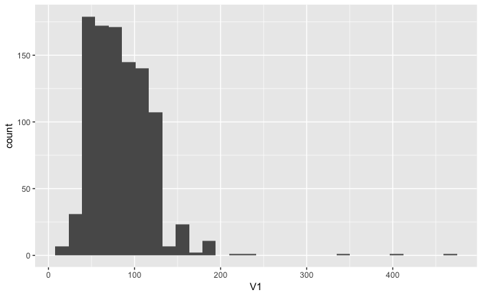

`r`r Bootstrap2 %>% ggplot(aes(x = V2)) + geom_histogram()

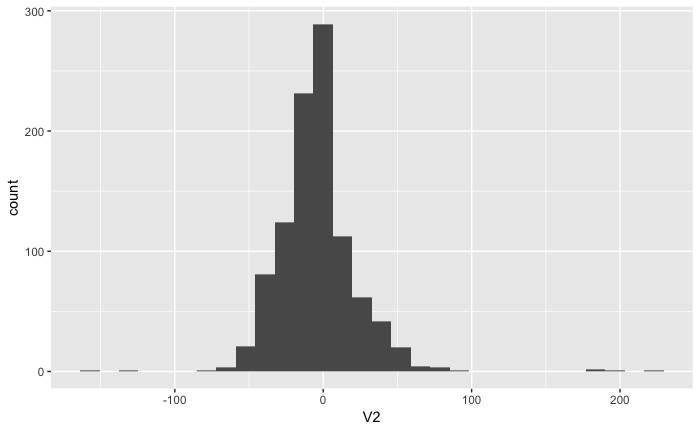

`r`r Bootstrap2 %>% ggplot(aes(x = V3)) + geom_histogram()

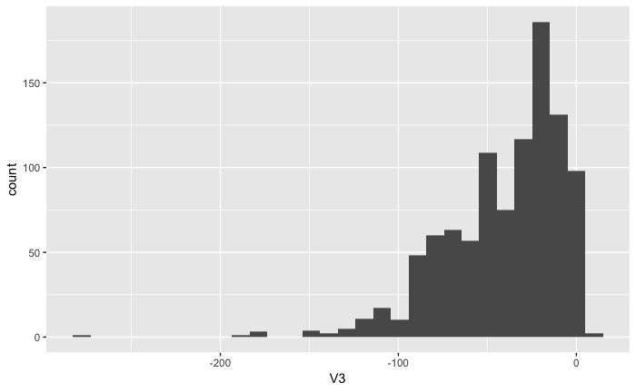

**Task 5.1.4 [3 pts] Calculate and report the bootstrap 95% confidence intervals for beta1, beta2, and beta3.**

`r`r #Finding bootstrap at 95% confidence interval confint(Bootstrap2)

| name | lower | upper | level | method | estimate |
| --- | --- | --- | --- | --- | --- |
| V1 | 31.44301 | 150.6970002 | 0.95 | percentile | 122.77500 |
| V2 | -48.96951 | 52.3098051 | 0.95 | percentile | -12.88780 |
| V3 | -115.28336 | -0.1417742 | 0.95 | percentile | -88.01347 |

## 6. [4 pts] Get ready for the census taker again!

Recall the model:
$$y = \frac{\beta_1}{1 + \exp(\beta_2 + \beta_3*x)}$$

**Task 6.1 Use the RMS model fit to estimate the expected US population (in millions) for the 2020 Census**

`r`r # Using model 486.8025140 / (1 + exp(4.0591554 + (-0.2075431 * 23)))

```
[1] 326.819
```

**Task 6.2 Use the MAD model fit to estimate the expected US population (in millions) for the 2020 Census**

`r`r #Using Model 512.4268595 / (1 + exp(4.1178662 + (-0.2054896 * 23)))

```
[1] 331.8346
```

[^1]: Ehrlich, Paul R; Ehrlich, Anne H (2004), One with Nineveh: Politics, Consumption, and the Human Future, Island Press/Shearwater Books, pp. 137, 182, see also pages 76–236